# DKI Calculations

Calculating DKI using the ambiR package.

There are several steps:

- Species data. Check the species names in the observation data for matches with names in the AMBI database. Where possible, correct names which do not match.
- Salinity. Find the salinity information necessary to calculate `DKI`.
- Calculate DKI. Perform the calculations.

# 1. Species observation data

## Read data

Read species observation data downloaded from ODA:

HentData_WDXSYOYGJE.csv.

```r
bf <- read_delim("data/HentData_WDXSYOYGJE.csv",
                 delim = ";", escape_double=FALSE,
                 locale=locale(decimal_mark = ",",
                               grouping_mark = ".",
                               encoding = "WINDOWS-1252"),
                 trim_ws = TRUE,
                 show_col_types = FALSE)
```

## Check species names

### Unique species names in observations

Get unique species names from the observation data

```r
species <- bf %>%
  distinct(Artsnavn)
```

Use the `.fix_name()` function from utils.R. This will do some simple corrections to species names e.g. replace any *indet.* in species names and remove any double spaces in names.

```r
species <- species %>%
  mutate(species = .fix_name(Artsnavn))  %>%
  distinct(Artsnavn, species)
```

### Match with AMBI

Check if there the species names can be matched with a name on the AMBI species list. By default, the `AMBI()` function will match a family name in the observations without *sp.* with a family name in AMBI where *sp.* is included. By using the `exact_species_match = TRUE` argument only *exact* matches will be found.

```r
species_match <- species %>%
  mutate(count=1)

species_match <- species_match %>%
  ambiR::AMBI(quiet = T)

species_match <- species_match$matched
```

For species which did have a match, replace the look-up name with the one matched in the AMBI list.

```r
species <- species_match %>%
  mutate(species = ifelse(is.na(species_matched),
                          species, species_matched)) %>%
  select(Artsnavn, species)
```

### Species names not matched

Select the species names which were not matched with species names in the AMBI database.

```r
species_unmatched <- species_match %>%
  filter(is.na(species_matched)) %>%
  distinct(Artsnavn, species) %>%
  arrange(Artsnavn)

# save the list
write.table(species_unmatched, file="results/species_unmatched.csv",
            sep=",", col.names=T, row.names=F, quote=T)


species_unmatched
```

```
# A tibble: 63 × 2
   Artsnavn                species
   <chr>                   <chr>
 1 AMPHIPODA               Amphipoda
 2 Amphipoda indet.        Amphipoda
 3 Anthrenochernes stellae Anthrenochernes stellae
 4 Astrorhiza  limicola    Astrorhiza limicola
 5 Atylus swammerdami      Atylus swammerdami
 6 Balanidae indet.        Balanidae
 7 Balanus sp.             Balanus sp.
 8 Bivalvia indet.         Bivalvia
 9 Brachyura indet.        Brachyura
10 Calanoida indet.        Calanoida
# ℹ 53 more rows
```

There are **63** *Artsnavn* which could not be matched with species in the AMBI database. They are listed in this file: species_unmatched.csv

### Check names in WoRMs

Species names which were not matched with the AMBI species list will be checked with the [WoRMS database](https://marinespecies.org/) using the `.GetSpeciesNameWoRMS()` function from utils.R. This can correct the cases where a deprecated species name has been recorded instead of the currently accepted name.

```r
species_unmatched <- species_unmatched %>%
  pull("species") %>%
  unique()

species_worms <- species_unmatched %>%
  purrr::map(.GetSpeciesNameWoRMS) %>%
  unlist()

species_unmatched <- data.frame(
  species=species_unmatched,
  speciesWoRMS= species_worms
)
```

Before comparing results from WoRMS with the existing species names, we will *fix* the names as we did previously.

For example, we need to remove parts within parenthesis from WoRMS names e.g. *Phascolion (Phascolion) strombus* because the AMBI list does not include these.

```r
species_unmatched <- species_unmatched  %>%
  mutate(speciesWoRMS = .fix_name(speciesWoRMS))
```

### Select names corrected in WoRMs

Now we will select only the WoRMS results where the species name returned by WoRMS is different from the existing species name. If a name we had already matches with the correct name in WoRMS, there is no need to update it.

```r
species_replace <- species_unmatched  %>%
  mutate(speciesWoRMS = ifelse(species==speciesWoRMS, NA, speciesWoRMS)) %>%
  filter(!is.na(speciesWoRMS))

species_replace
```

```
                         species                 speciesWoRMS
1             Atylus swammerdami      Nototropis swammerdamei
2                    Balanus sp.                      Balanus
3         Callinassa subterranea      Callianassa subterranea
4               Caulleriella sp.                 Caulleriella
5        Cheirocratus sundevalli     Cheirocratus sundevallii
6              Corophium bonelli     Crassicorophium bonellii
7                        Donacia                       Tethya
8         Diastyloides biplicata      Diastyloides biplicatus
9               Gattyana cirrosa            Gattyana cirrhosa
10               Gnathia oxyurea             Gnathia oxyuraea
11         Goniadella bobretzkii         Goniadella bobrezkii
12            Hemilamprops rosea          Hemilamprops roseus
13                   Hydracarina                 Hydrachnidia
14                 Hydrobius sp.                    Hydrobius
15                Idotea viridis              Idotea chelipes
16              Lapidoplax buski            Labidoplax buskii
17        Lepidochitona cinereus        Lepidochitona cinerea
18       Lipobranchus jeffreysii     Lipobranchius jeffreysii
19            Macropodia rostata          Macropodia rostrata
20                     Nemertini                     Nemertea
21 Petaloproctus tenuis borealis       Petaloproctus borealis
22            Phascolion strombi Phascolion strombus strombus
23       Phoxocephalus holboelli       Phoxocephalus holbolli
24              Phthisica marina              Phtisica marina
25         Pseudione tuberculata           Pseudione borealis
26        Pseudocuma longicornis        Pseudocuma longicorne
27            Pseudocuma similis              Chama pulchella
28          Terebellides stroemi        Terebellides stroemii
```

This gives **28** corrections of species names.

### Make corrections in our original species list

Now we will use the correct names returned by WoRMS to change the table matching `Artsnavn` to `species`

```r
species2 <- species %>%
  select(Artsnavn, species) %>%
  left_join(species_replace, by="species")

species2 <- species2 %>%
  mutate(species=ifelse(is.na(speciesWoRMS),species,speciesWoRMS)) %>%
  distinct(Artsnavn, species)
```

### Match with AMBI - 2nd attempt

Now try to match the updated species list with AMBI species list.

```r
species2_match <- species2 %>%
  mutate(count=1)

species2_match <- species2_match %>%
  ambiR::AMBI(quiet = T)

species2_match <- species2_match$matched
```

### Species names not matched on 2nd attempt

Now select only the species which were not matched.

```r
species2_unmatched <- species2_match %>%
  filter(is.na(species_matched)) %>%
  distinct(Artsnavn, species) %>%
  arrange(Artsnavn)

species2_unmatched
```

```
# A tibble: 42 × 2
   Artsnavn                species
   <chr>                   <chr>
 1 AMPHIPODA               Amphipoda
 2 Amphipoda indet.        Amphipoda
 3 Anthrenochernes stellae Anthrenochernes stellae
 4 Astrorhiza  limicola    Astrorhiza limicola
 5 Balanidae indet.        Balanidae
 6 Balanus sp.             Balanus
 7 Bivalvia indet.         Bivalvia
 8 Brachyura indet.        Brachyura
 9 Calanoida indet.        Calanoida
10 Campanulariidae indet.  Campanulariidae
# ℹ 32 more rows
```

### *Fuzzy* matching

The last thing we can try is to do a *fuzzy* join of species names using the [fuzzyjoin package](https://github.com/dgrtwo/fuzzyjoin). This joins species names in observations with species names in AMBI which are similar, rather than identical.

We can limit the *fuzzyjoin* function to return only very similar matches by setting the `max_dist` argument to `1`. The default values is `2`. This will return more possible matches but some of them are likely to be incorrect. For example *Balanidae sp.* (a family of barnacles) is matched with *Maldanidae sp.* (a family of polychaetes). In any case, it is a good idea to check the results.

```r
species2_fuzzy <- species2_unmatched %>%
  distinct(species) %>%
  rename(species_match=species)


species2_fuzzy <- species2_fuzzy %>%
  fuzzyjoin::stringdist_left_join(ambiR::AMBI_species(),
                                  max_dist=1,
                                  by=c("species_match"="species"),
                                  distance_col = "dist")


species2_replace <- species2_fuzzy %>%
  filter(!is.na(species)) %>%
  select(species=species_match, species_fuzzy=species)
```

Using the strictest match specifications (`max_dist = 1`), then 2 *fuzzy* matches are found:

```r
species2_replace
```

```
# A tibble: 2 × 2
  species     species_fuzzy
  <chr>       <chr>
1 Priapulidae Priapulida
2 Terebellida Terebellidae
```

### Update species list

```r
species3 <- species2 %>%
  select(Artsnavn, species) %>%
  left_join(species2_replace, by="species")

species3 <- species3 %>%
  mutate(species=ifelse(is.na(species_fuzzy),species,species_fuzzy)) %>%
  select(Artsnavn, species) %>%
  arrange(Artsnavn, species)


species3_match <- species3 %>%
  mutate(count=1) %>%
  ambiR::AMBI(quiet = T)

species3_match <- species3_match$matched %>%
  mutate(AMBI=ifelse(is.na(group),F,T)) %>%
  select(Artsnavn, species, AMBI, AMBI_group=group)

# save the list

write.table(species3_match, file="results/species_names.csv",
            sep=",", col.names=T, row.names=F, quote=T,
            na="")
```

The full list of species names after corrections is here: species_names.csv

## Update observation data

Add the corrected species names to the observation data

```r
bf <- bf %>%
  left_join(species3, by="Artsnavn")
```

# 2. Salinity

After calculating AMBI, We will use the mean salinity at each sampling site to normalize DKI.

## Read salinity data

Read the data downloaded from ODA as csv.

```r
# read salinity data (not saved in github repository - the file is 50 MB)

psal <- read_delim("data/HentData_LFLXTQXRGW.csv",
                   delim = ";", escape_double=FALSE,
                   locale=locale(decimal_mark = ",",
                                 grouping_mark = ".",
                                 encoding = "WINDOWS-1252"),
                   trim_ws = TRUE,
                   show_col_types = FALSE)

# strictly speaking the filter by Parameter is not necessary
# keeping it in case CTD data including other parameters is used

psal <- psal %>%
  filter(Parameter=="Salinitet") %>%
  select(os_nr=ObservationsStedNr,
         os_navn=ObservationsStedNavn,
         Længde, Bredde,
         Dato,
         z = `Dybde (m)`,
         psal = KorrigeretResultat)
```

## Find deepest salinity measurement in each profile

Arrange the data on each sample date by depth and take the deepest measurement

```r
# find deepest salinity measurement for each profile
psal <- psal %>%
  group_by(os_nr, os_navn, Længde, Bredde, Dato) %>%
  arrange(desc(z)) %>%
  slice(1) %>%
  ungroup()
```

## Find average salinity

Calculate the average salinity within each waterbody ()

```r
# find average for each ov
psal <- psal %>%
  group_by(os_nr, os_navn) %>%
  summarise(lon=median(Længde),
            lat=median(Bredde),
            psal=mean(psal, na.rm=T), .groups = "drop")
```

## Join salinity data to benthic fauna sampling sites

### Convert salinity mean values to spatial data

Use the latitude and longitude information in the salinity data to create a spatial data (`sf`) object and then transform to UTM-32

```r
psal <- psal %>%
  sf::st_as_sf(coords=c("lon","lat"), crs=sf::st_crs(4326)) %>%
  sf::st_transform(crs=sf::st_crs(25832))
```

### Unique locations for bottom fauna samples

Find unique locations for bottom fauna samples and convert to spatial data

```r
# get unique locations for bottom fauna samples

bf_posn <- bf %>%
  select(os_nr=ObservationsStedNr,
         os_navn=ObservationsStedNavn,
         lon = `Prøvetagnings Længdegrad`,
         lat = `Pprøvtagnings Breddegrad`) %>%
  group_by(os_nr, os_navn) %>%
  summarise(lon = median(lon),
            lat=median(lat), .groups="drop")

bf_posn <- bf_posn %>%
  sf::st_as_sf(coords=c("lon","lat"), crs=sf::st_crs(4326)) %>%
  sf::st_transform(crs=sf::st_crs(25832))
```

### Match benthic fauna sample and salinity locations

Find the closest salinity location to each benthic fauna sampling position

```r
# find closest salinity point for each bottom fauna position
closest <- sf::st_nearest_feature(bf_posn, psal)

bf_posn$psal <- psal$psal[closest]

bf_psal <- bf_posn %>%
  sf::st_drop_geometry() %>%
  select(os_nr, psal)
```

Now we have a mean salinity value for each observation position in the benthic fauna sampling data

```r
bf_psal
```

```
# A tibble: 76 × 2
      os_nr  psal
      <dbl> <dbl>
 1 90000958  33.7
 2 90000961  15.8
 3 91000051  34.5
 4 91000078  34.4
 5 91000079  34.5
 6 91000080  34.5
 7 91000081  34.1
 8 91000082  34.7
 9 91000083  34.4
10 91000084  34.7
# ℹ 66 more rows
```

# 3. Calculate DKI

## Calculate DKI with pooled samples

### Group samples

For DKI v2, samples are pooled in groups to give a total sampling area of approximately 0.1 m^2

```r
bf_pooled <- bf %>%
  rename(os_nr=ObservationsStedNr,
         os_navn=ObservationsStedNavn)  %>%
  mutate(samples_per_group = round(1000/`Prøveredskabsareal (cm2)`, digits = 0))


# add pooled sample ID
bf_pooled <- bf_pooled %>%
  DKI_group_samples(
    group_vars=c("os_navn","os_nr","Dato","Prøvetagningsudstyr"),
    column_sample_id ="Prøvetagningsnummer",
    column_samples_per_group="samples_per_group"
    )

# summarise within pooled samples
bf_pooled <- bf_pooled %>%
  group_by(os_nr, os_navn, Dato, Tid,
           Prøvetagningsudstyr, grp_id,
           species) %>%
  summarise(n=sum(`Antal (stk)`), .groups="drop")


# first run with AMBI
```

### Calculate AMBI for pooled samples

Instead of the original sample nr *Prøvetagningsnummer*, we use the ID for the grouped samples ( *grp_id* ) to identify replicates when calculating AMBI.

```r
ambi_res_pooled <- ambiR::AMBI(bf_pooled,
                    by=c("os_nr", "os_navn", "Dato", "Tid"),
                    var_species = "species",
                    var_count = "n",
                    var_rep = "grp_id",
                    interactive = F,
                    quiet= T)

ambi_pooled <- ambi_res_pooled$AMBI
```

By default, the name of every species which could not be matched with a name in the AMBI database is listed when calling the `AMBI()` function. Here we have used the `quiet = TRUE` option.

Remember to check which species names were not matched. We have already tested our data before calculating AMBI but it is always a good idea to check once more.

```r
not_found <- ambi_res_pooled$matched %>%
  filter(is.na(group)) %>%
  distinct(species)

not_found
```

```
# A tibble: 37 × 1
   species
   <chr>
 1 Foraminifera
 2 Polychaeta
 3 Gastropoda
 4 Bivalvia
 5 Pisces
 6 Amphipoda
 7 Chama pulchella
 8 Caudofoveata
 9 Terebellomorpha
10 Porifera
# ℹ 27 more rows
```

Check also any warnings generated. If the total number of species is too small or the total number of individuals, then AMBI should not be used.

```r
ambi_res_pooled$warnings
```

```
# A tibble: 2 × 5
     os_nr os_navn      Dato   Tid warning
     <dbl> <chr>       <dbl> <dbl> <chr>
1 91650033 LISD0025 20230417  1200 The (not null) number of species is less tha…
2 91650033 LISD0025 20230417  1200 The (not null) number of individuals is less…
```

### Add salinity information

To calculate DKI from the AMBI results for pooled samples, we need to join them to the salinity information calculated above.

```r
ambi_pooled <- ambi_pooled %>%
  select(os_nr, os_navn, Dato, Tid, AMBI, H, S, fNA, N) %>%
  left_join(bf_psal, by="os_nr")
```

### Calculate DKI for pooled samples

Now we can calculate DKI

```r
dki_pooled <- ambi_pooled %>%
  mutate(DKI = DKI2(AMBI, H, N, psal))

# save the results

write.table(dki_pooled, file="results/DKI_pooled.csv",
            sep=",", col.names=T, row.names=F, quote=T)

dki_pooled
```

```
# A tibble: 77 × 11
      os_nr os_navn       Dato   Tid  AMBI     H     S     fNA     N  psal   DKI
      <dbl> <chr>        <dbl> <dbl> <dbl> <dbl> <int>   <dbl> <dbl> <dbl> <dbl>
 1 90000958 413       20230511  1200  1.07  3.13    38 0         308  33.7 0.733
 2 90000961 444       20230227  1200  2.74  2.11     6 0          53  15.8 0.690
 3 91000051 HSD_G_OCM 20230422  1200  1.48  3.10    72 1.32e-2  1439  34.5 0.699
 4 91000078 DMU1025   20230421  1200  1.43  3.08    73 0        2302  34.4 0.701
 5 91000079 DMU1026   20230421  1200  1.62  2.69    68 0        2131  34.5 0.648
 6 91000080 DMU1027   20230422  1200  1.46  3.05    74 1.05e-3  1908  34.5 0.695
 7 91000081 DMU1044   20230421  1200  1.36  1.12    39 0        4953  34.1 0.514
 8 91000082 DMU1046   20230423  1200  1.67  3.68    63 0        1382  34.7 0.741
 9 91000083 DMU1047   20230423  1200  1.57  1.89    52 6.35e-4  1575  34.4 0.574
10 91000084 DMU1048   20230423  1200  1.62  4.09    64 0         758  34.7 0.784
# ℹ 67 more rows
```

Download the results for DKI based on pooled samples: DKI_pooled.csv

## Calculate DKI with individual samples

Here DKI is based on AMBI calculated from individual ungrouped samples.

### Calculate AMBI

This time we use the original sample ID *Prøvetagningsnummer* to identify replicates when calculating AMBI.

```r
bf2 <- bf %>%
  select(os_nr=ObservationsStedNr,
         os_navn=ObservationsStedNavn,
         Dato,
         Tid,
         n=`Antal (stk)`,
         sample_nr = Prøvetagningsnummer,
         species)

ambi_res <- ambiR::AMBI(bf2,
                     by=c("os_nr", "os_navn", "Dato", "Tid"),
                     var_species = "species",
                     var_count = "n",
                     var_rep = "sample_nr",
                     interactive = F,
                     quiet= T)


ambi <- ambi_res$AMBI
```

Check warnings generated by the `AMBI()`function

```r
ambi_res_pooled$warnings
```

```
# A tibble: 2 × 5
     os_nr os_navn      Dato   Tid warning
     <dbl> <chr>       <dbl> <dbl> <chr>
1 91650033 LISD0025 20230417  1200 The (not null) number of species is less tha…
2 91650033 LISD0025 20230417  1200 The (not null) number of individuals is less…
```

### Add salinity information

As with the grouped samples, we still need salinity values to calculate DKI.

```r
ambi <- ambi %>%
  select(os_nr, os_navn, Dato, Tid, AMBI, H, S, fNA, N) %>%
  left_join(bf_psal, by="os_nr")
```

### Calculate DKI

Calculate DKI from AMBI results and salinity.

```r
dki <- ambi %>%
  select(os_nr, os_navn, Dato, Tid, AMBI, H, S, fNA, N) %>%
  left_join(bf_psal, by="os_nr") %>%
  mutate(DKI = DKI2(AMBI, H, N, psal))

# save the results

write.table(dki, file="results/DKI.csv",
            sep=",", col.names=T, row.names=F, quote=T)

dki
```

```
# A tibble: 77 × 11
      os_nr os_navn       Dato   Tid  AMBI     H     S     fNA     N  psal   DKI
      <dbl> <chr>        <dbl> <dbl> <dbl> <dbl> <int>   <dbl> <dbl> <dbl> <dbl>
 1 90000958 413       20230511  1200  1.10  3.13    38 0         308  33.7 0.731
 2 90000961 444       20230227  1200  2.82  2.11     6 0          53  15.8 0.684
 3 91000051 HSD_G_OCM 20230422  1200  1.48  3.10    72 1.32e-2  1439  34.5 0.698
 4 91000078 DMU1025   20230421  1200  1.37  3.08    73 0        2302  34.4 0.705
 5 91000079 DMU1026   20230421  1200  1.61  2.69    68 0        2131  34.5 0.649
 6 91000080 DMU1027   20230422  1200  1.49  3.05    74 1.05e-3  1908  34.5 0.694
 7 91000081 DMU1044   20230421  1200  1.32  1.12    39 0        4953  34.1 0.517
 8 91000082 DMU1046   20230423  1200  1.65  3.68    63 0        1382  34.7 0.742
 9 91000083 DMU1047   20230423  1200  1.57  1.89    52 6.35e-4  1575  34.4 0.574
10 91000084 DMU1048   20230423  1200  1.63  4.09    64 0         758  34.7 0.783
# ℹ 67 more rows
```

Download the results for DKI based on individual samples: DKI.csv

# 4. Compare pooled and individual

Compare DKI based on AMBI calculated from individual samples with DKI from pooled samples

```r
dki_compare <- dki %>%
  select(os_nr, os_navn, Dato, Tid, psal, DKI) %>%
  left_join(dki_pooled %>%
              select(os_nr, Dato, Tid, DKI_pooled=DKI),
            by=c("os_nr", "Dato", "Tid"))

dki_compare <- dki_compare %>%
  mutate(diff=DKI_pooled-DKI)

# save the results

write.table(dki_compare, file="results/DKI_comparison.csv",
            sep=",", col.names=T, row.names=F, quote=T)
```

Download the data for the comparison of DKI for pooled and individual samples: DKI_comparison.csv

## Show comparison graphically

Plot the different DKI results

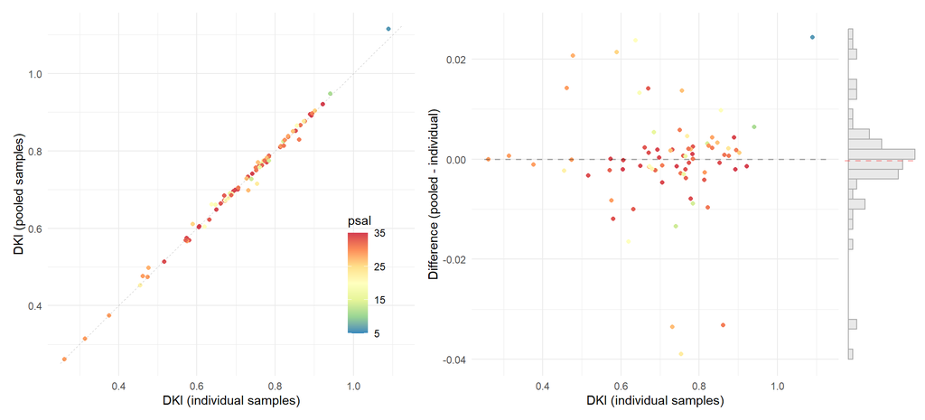

```r
dki_min <- min(dki_compare$DKI)
dki_min_p <- min(dki_compare$DKI_pooled)
dki_min <- pmax(dki_min, dki_min_p)

dki_max <- max(dki_compare$DKI)
dki_max_p <- max(dki_compare$DKI_pooled)
dki_max <- pmax(dki_max, dki_max_p)

hist_bin <- 0.002
diff_min <- hist_bin*floor(min(dki_compare$diff)/hist_bin)
diff_max <- hist_bin*ceiling(max(dki_compare$diff)/hist_bin)
diff_mean <- mean(dki_compare$diff)


# data for 1:1 line
df11 <- data.frame(x=c(dki_min-0.01, dki_max+0.01)) %>%
  mutate(y=x)

df00 <- data.frame(x=c(dki_min-0.01, dki_max+0.01)) %>%
  mutate(y=c(0,0))

p1 <- ggplot() +
  geom_point(data=dki_compare,
             aes(x=DKI, y=DKI_pooled, colour = psal)) +
  geom_line(data=df11, aes(x=x,y=y), colour="black",
            linetype=2, linewidth=0.3, alpha=0.3) +
  scale_color_distiller(palette = "Spectral",
                        limits=c(5,35), breaks=c(5,15,25,35)) +
  theme_minimal() +
  scale_x_continuous("DKI (individual samples)") +
  scale_y_continuous("DKI (pooled samples)") +
  coord_cartesian(xlim = c(dki_min, dki_max),
                  ylim = c(dki_min, dki_max)) +
  theme(legend.position = "inside",
        legend.position.inside = c(0.8,0.1),
        legend.justification = c(0,0))

p2 <- ggplot() +
  geom_point(data=dki_compare,
             aes(x=DKI, y=diff, colour = psal)) +
    geom_line(data=df00, aes(x=x,y=y), colour="black",
            linetype=2, linewidth=0.6, alpha=0.3) +
  scale_color_distiller(palette = "Spectral",
                        limits=c(5,35), breaks=c(5,15,25,35),
                        guide="none") +
  scale_x_continuous("DKI (individual samples)") +
  scale_y_continuous("Difference (pooled - individual)") +
  theme_minimal() +
  coord_cartesian(xlim=c(dki_min, dki_max),
                  ylim=c(diff_min,diff_max))

p3 <- ggplot() +
  geom_histogram(data=dki_compare,
                 breaks=seq(diff_min, diff_max, hist_bin),
               aes(y=diff),
                 alpha=0.5,
               colour = 'darkgrey',
               fill = 'lightgrey',
               orientation = "y") +
  geom_hline(yintercept = diff_mean, colour="red",
            linetype=2, linewidth=0.6, alpha=0.3) +
  coord_cartesian(ylim=c(diff_min,diff_max)) +
  theme_void()


p <- p1 + p2 + p3 +
  plot_layout(ncol=3, widths = c(5,5,1))
p
```

```r
ggsave(p, filename="results/compare_DKI.png",
       height=5, width=11, units="in", dpi=300)
```

The dotted grey line in the left-hand figure shows the 1:1 line (DKI for the two methods is equal). The dotted grey line in the right-hand figure shows *Difference = 0*. The red dotted line in the histogram shows the mean difference (**-0.000273**)